# ExtraaLearn Project

## Context

The EdTech industry has been surging in the past decade immensely, and according to a forecast, the Online Education market would be worth $286.62bn by 2023 with a compound annual growth rate (CAGR) of 10.26% from 2018 to 2023. The modern era of online education has enforced a lot in its growth and expansion beyond any limit. Due to having many dominant features like ease of information sharing, personalized learning experience, transparency of assessment, etc, it is now preferable to traditional education.

In the present scenario due to the Covid-19, the online education sector has witnessed rapid growth and is attracting a lot of new customers. Due to this rapid growth, many new companies have emerged in this industry. With the availability and ease of use of digital marketing resources, companies can reach out to a wider audience with their offerings. The customers who show interest in these offerings are termed as leads. There are various sources of obtaining leads for Edtech companies, like

- The customer interacts with the marketing front on social media or other online platforms.
- The customer browses the website/app and downloads the brochure
- The customer connects through emails for more information.

The company then nurtures these leads and tries to convert them to paid customers. For this, the representative from the organization connects with the lead on call or through email to share further details.

## Objective

ExtraaLearn is an initial stage startup that offers programs on cutting-edge technologies to students and professionals to help them upskill/reskill. With a large number of leads being generated on a regular basis, one of the issues faced by ExtraaLearn is to identify which of the leads are more likely to convert so that they can allocate resources accordingly. You, as a data scientist at ExtraaLearn, have been provided the leads data to:

- Analyze and build an ML model to help identify which leads are more likely to convert to paid customers,
- Find the factors driving the lead conversion process
- Create a profile of the leads which are likely to convert

## Data Description

The data contains the different attributes of leads and their interaction details with ExtraaLearn. The detailed data dictionary is given below.

**Data Dictionary**

- ID: ID of the lead
- age: Age of the lead
- current_occupation: Current occupation of the lead. Values include 'Professional','Unemployed',and 'Student'
- first_interaction: How did the lead first interacted with ExtraaLearn. Values include 'Website', 'Mobile App'
- profile_completed: What percentage of profile has been filled by the lead on the website/mobile app. Values include Low - (0-50%), Medium - (50-75%), High (75-100%)
- website_visits: How many times has a lead visited the website
- time_spent_on_website: Total time spent on the website
- page_views_per_visit: Average number of pages on the website viewed during the visits.
- last_activity: Last interaction between the lead and ExtraaLearn.
  - Email Activity: Seeking for details about program through email, Representative shared information with lead like brochure of program , etc
  - Phone Activity: Had a Phone Conversation with representative, Had conversation over SMS with representative, etc
  - Website Activity: Interacted on live chat with representative, Updated profile on website, etc
- print_media_type1: Flag indicating whether the lead had seen the ad of ExtraaLearn in the Newspaper.
- print_media_type2: Flag indicating whether the lead had seen the ad of ExtraaLearn in the Magazine.
- digital_media: Flag indicating whether the lead had seen the ad of ExtraaLearn on the digital platforms.
- educational_channels: Flag indicating whether the lead had heard about ExtraaLearn in the education channels like online forums, discussion threads, educational websites, etc.
- referral: Flag indicating whether the lead had heard about ExtraaLearn through reference.
- status: Flag indicating whether the lead was converted to a paid customer or not.

## Importing necessary libraries and data

```python
# import core data manipulation libs
import pandas as pd
import numpy as np
# import viz libs
import seaborn as sns
import matplotlib.pyplot as plt

# For chi-squared test to find relationships between categorical variables
from scipy.stats import chi2_contingency

# Model selection and validation
from sklearn.model_selection import (train_test_split, cross_val_score, GridSearchCV)
# Decision tree models and visualization
from sklearn.tree import (DecisionTreeClassifier, DecisionTreeRegressor, plot_tree)

# Performance metrics
import sklearn.metrics as metrics
from sklearn.metrics import (
    confusion_matrix,
    classification_report,
    f1_score,
    r2_score,
    mean_squared_error,
    mean_absolute_error,
    accuracy_score,
    recall_score,
    make_scorer,
)
# Random Forest for classification
from sklearn.ensemble import RandomForestClassifier
```

```python
from google.colab import drive
drive.mount('/content/drive')
```

## Data Overview

- Observations
- Sanity checks

```python
data = pd.read_csv('/content/drive/My Drive/Colab_Notebooks/ExtraaLearn.csv')
# checking the shape of the data
data.shape
```

```
(4612, 15)
```

```python
# get the first 5 rows of the data
data.head()
```

|  | ID | age | current_occupation | first_interaction | profile_completed | website_visits | time_spent_on_website | page_views_per_visit | last_activity | print_media_type1 | print_media_type2 | digital_media | educational_channels | referral | status |
| --- | --- | --- | --- | --- | --- | --- | --- | --- | --- | --- | --- | --- | --- | --- | --- |
| 0 | EXT001 | 57 | Unemployed | Website | High | 7 | 1639 | 1.861 | Website Activity | Yes | No | Yes | No | No | 1 |
| 1 | EXT002 | 56 | Professional | Mobile App | Medium | 2 | 83 | 0.320 | Website Activity | No | No | No | Yes | No | 0 |
| 2 | EXT003 | 52 | Professional | Website | Medium | 3 | 330 | 0.074 | Website Activity | No | No | Yes | No | No | 0 |
| 3 | EXT004 | 53 | Unemployed | Website | High | 4 | 464 | 2.057 | Website Activity | No | No | No | No | No | 1 |
| 4 | EXT005 | 23 | Student | Website | High | 4 | 600 | 16.914 | Email Activity | No | No | No | No | No | 0 |

```python
# get the last 5 rows of the data
data.tail()
```

|  | ID | age | current_occupation | first_interaction | profile_completed | website_visits | time_spent_on_website | page_views_per_visit | last_activity | print_media_type1 | print_media_type2 | digital_media | educational_channels | referral | status |
| --- | --- | --- | --- | --- | --- | --- | --- | --- | --- | --- | --- | --- | --- | --- | --- |
| 4607 | EXT4608 | 35 | Unemployed | Mobile App | Medium | 15 | 360 | 2.170 | Phone Activity | No | No | No | Yes | No | 0 |
| 4608 | EXT4609 | 55 | Professional | Mobile App | Medium | 8 | 2327 | 5.393 | Email Activity | No | No | No | No | No | 0 |
| 4609 | EXT4610 | 58 | Professional | Website | High | 2 | 212 | 2.692 | Email Activity | No | No | No | No | No | 1 |
| 4610 | EXT4611 | 57 | Professional | Mobile App | Medium | 1 | 154 | 3.879 | Website Activity | Yes | No | No | No | No | 0 |
| 4611 | EXT4612 | 55 | Professional | Website | Medium | 4 | 2290 | 2.075 | Phone Activity | No | No | No | No | No | 0 |

```python
# get data datatypes and non-nulls
data.info()
```

```
<class 'pandas.core.frame.DataFrame'>
RangeIndex: 4612 entries, 0 to 4611
Data columns (total 15 columns):
 #   Column                 Non-Null Count  Dtype
---  ------                 --------------  -----
 0   ID                     4612 non-null   object
 1   age                    4612 non-null   int64
 2   current_occupation     4612 non-null   object
 3   first_interaction      4612 non-null   object
 4   profile_completed      4612 non-null   object
 5   website_visits         4612 non-null   int64
 6   time_spent_on_website  4612 non-null   int64
 7   page_views_per_visit   4612 non-null   float64
 8   last_activity          4612 non-null   object
 9   print_media_type1      4612 non-null   object
 10  print_media_type2      4612 non-null   object
 11  digital_media          4612 non-null   object
 12  educational_channels   4612 non-null   object
 13  referral               4612 non-null   object
 14  status                 4612 non-null   int64
dtypes: float64(1), int64(4), object(10)
memory usage: 540.6+ KB
```

```python
# double checking that we dont have any nulls
data.isnull().sum()
```

```
ID                       0
age                      0
current_occupation       0
first_interaction        0
profile_completed        0
website_visits           0
time_spent_on_website    0
page_views_per_visit     0
last_activity            0
print_media_type1        0
print_media_type2        0
digital_media            0
educational_channels     0
referral                 0
status                   0
dtype: int64
```

```python
# getting a rough statistical picture of the data
data.describe()
```

|  | age | website_visits | time_spent_on_website | page_views_per_visit | status |
| --- | --- | --- | --- | --- | --- |
| count | 4612.000000 | 4612.000000 | 4612.000000 | 4612.000000 | 4612.000000 |
| mean | 46.201214 | 3.566782 | 724.011275 | 3.026126 | 0.298569 |
| std | 13.161454 | 2.829134 | 743.828683 | 1.968125 | 0.457680 |
| min | 18.000000 | 0.000000 | 0.000000 | 0.000000 | 0.000000 |
| 25% | 36.000000 | 2.000000 | 148.750000 | 2.077750 | 0.000000 |
| 50% | 51.000000 | 3.000000 | 376.000000 | 2.792000 | 0.000000 |
| 75% | 57.000000 | 5.000000 | 1336.750000 | 3.756250 | 1.000000 |
| max | 63.000000 | 30.000000 | 2537.000000 | 18.434000 | 1.000000 |

```python
# get duplicates
data.duplicated().sum()
```

```
0
```

**At the start of our notebook, we loaded our data and checked it thoroughly. We're happy to report that our data is clean, with no duplicates, missing values, or need for changes. This makes our analysis straightforward and reliable.**

## Exploratory Data Analysis (EDA)

- EDA is an important part of any project involving data.
- It is important to investigate and understand the data better before building a model with it.
- A few questions have been mentioned below which will help you approach the analysis in the right manner and generate insights from the data.
- A thorough analysis of the data, in addition to the questions mentioned below, should be done.

**Questions**

1. Leads will have different expectations from the outcome of the course and the current occupation may play a key role in getting them to participate in the program. Find out how current occupation affects lead status.
2. The company's first impression on the customer must have an impact. Do the first channels of interaction have an impact on the lead status?
3. The company uses multiple modes to interact with prospects. Which way of interaction works best?
4. The company gets leads from various channels such as print media, digital media, referrals, etc. Which of these channels have the highest lead conversion rate?
5. People browsing the website or mobile application are generally required to create a profile by sharing their personal data before they can access additional information.Does having more details about a prospect increase the chances of conversion?

### Univariate Analysis

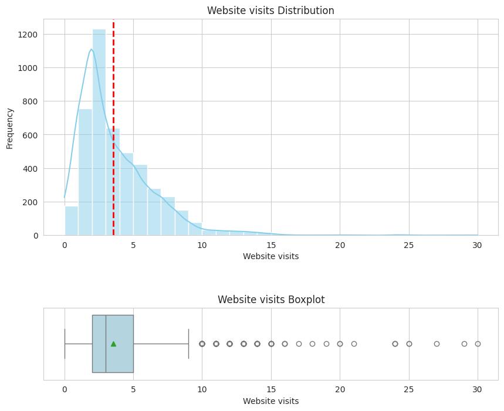

```python
fig, axs = plt.subplots(2, 1, figsize=(10, 8), gridspec_kw={'height_ratios': [3, 1], 'hspace': 0.5})

# Histogram with Density Plot on the first subplot
sns.histplot(data['website_visits'], kde=True, bins=30, color='skyblue', ax=axs[0])
axs[0].axvline(data['website_visits'].mean(), color='red', linestyle='--', linewidth=2)
axs[0].set_title('Website visits Distribution')
axs[0].set_xlabel('Website visits')
axs[0].set_ylabel('Frequency')

# Boxplot on the second subplot
sns.boxplot(x=data['website_visits'], color='lightblue', ax=axs[1], showmeans=True)
axs[1].set_title('Website visits Boxplot')
axs[1].set_xlabel('Website visits')
axs[1].set_ylabel('')

plt.show()
```

**The graph shows that the data is right-skewed, indicating that while the majority of people visit the page 3 times, there are a small number who visit more than 9 times.**

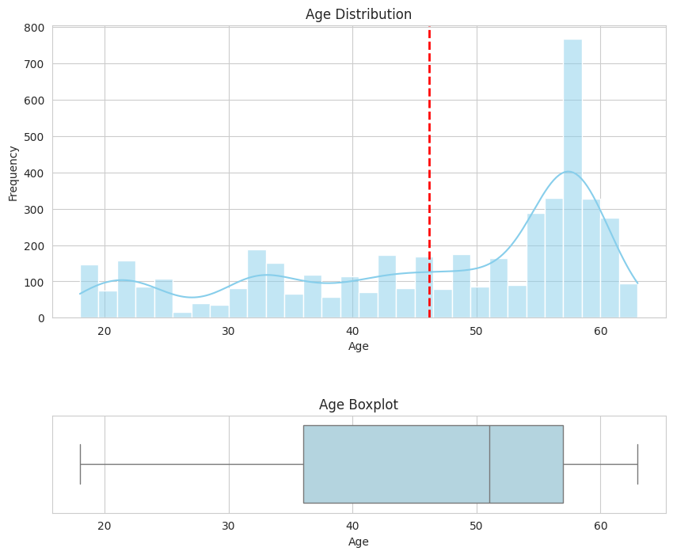

```python
fig, axs = plt.subplots(2, 1, figsize=(10, 8), gridspec_kw={'height_ratios': [3, 1], 'hspace': 0.5})

# Histogram with Density Plot on the first subplot
sns.histplot(data['age'], kde=True, bins=30, color='skyblue', ax=axs[0])
axs[0].axvline(data['age'].mean(), color='red', linestyle='--', linewidth=2)
axs[0].set_title('Age Distribution')
axs[0].set_xlabel('Age')
axs[0].set_ylabel('Frequency')

# Boxplot on the second subplot
sns.boxplot(x=data['age'], color='lightblue', ax=axs[1])
axs[1].set_title('Age Boxplot')
axs[1].set_xlabel('Age')
axs[1].set_ylabel('')

plt.show()
```

**In conclusion, our analysis of age reveals no outliers within the dataset, highlighting a client base that predominantly consists of older individuals. The distribution is left-skewed, indicating a concentration of higher ages. Notably, the most common age range among our clients falls between 54 and 57 years old.**

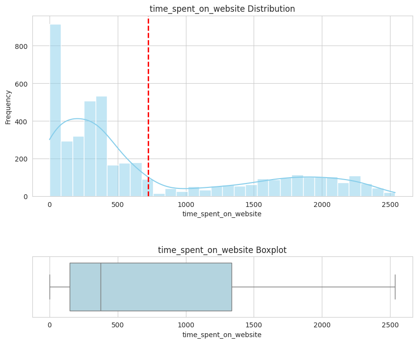

```python
fig, axs = plt.subplots(2, 1, figsize=(10, 8), gridspec_kw={'height_ratios': [3, 1], 'hspace': 0.5})

# Histogram with Density Plot on the first subplot
sns.histplot(data['time_spent_on_website'], kde=True, bins=30, color='skyblue', ax=axs[0])
axs[0].axvline(data['time_spent_on_website'].mean(), color='red', linestyle='--', linewidth=2)
axs[0].set_title('time_spent_on_website Distribution')
axs[0].set_xlabel('time_spent_on_website')
axs[0].set_ylabel('Frequency')

# Boxplot on the second subplot
sns.boxplot(x=data['time_spent_on_website'], color='lightblue', ax=axs[1])
axs[1].set_title('time_spent_on_website Boxplot')
axs[1].set_xlabel('time_spent_on_website')
axs[1].set_ylabel('')

plt.show()
```

**The analysis of time spent on the website reveals a right-skewed distribution with no outliers, indicating that most people spend less than approximately 1300 units of time on the site.**

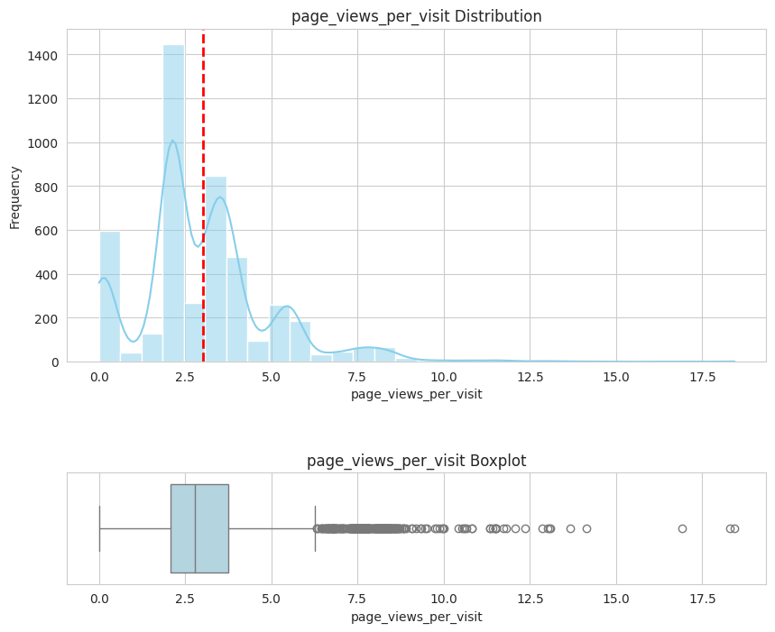

```python
fig, axs = plt.subplots(2, 1, figsize=(10, 8), gridspec_kw={'height_ratios': [3, 1], 'hspace': 0.5})

# Histogram with Density Plot on the first subplot
sns.histplot(data['page_views_per_visit'], kde=True, bins=30, color='skyblue', ax=axs[0])
axs[0].axvline(data['page_views_per_visit'].mean(), color='red', linestyle='--', linewidth=2)
axs[0].set_title('page_views_per_visit Distribution')
axs[0].set_xlabel('page_views_per_visit')
axs[0].set_ylabel('Frequency')

# Boxplot on the second subplot
sns.boxplot(x=data['page_views_per_visit'], color='lightblue', ax=axs[1])
axs[1].set_title('page_views_per_visit Boxplot')
axs[1].set_xlabel('page_views_per_visit')
axs[1].set_ylabel('')

plt.show()
```

**The analysis of pages viewed per visit shows a multimodal and slightly right-skewed distribution, with outliers present. The frequency of visits tends to decrease after approximately 6 page views per day.**

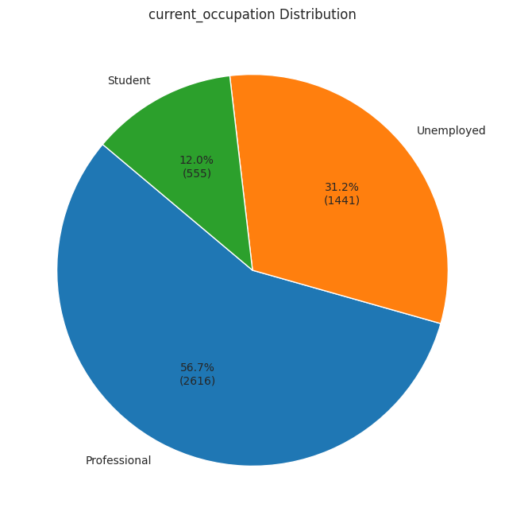

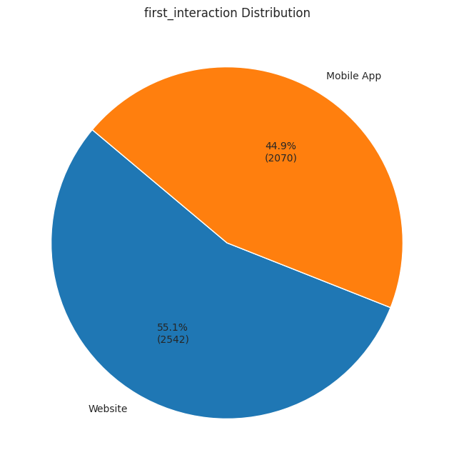

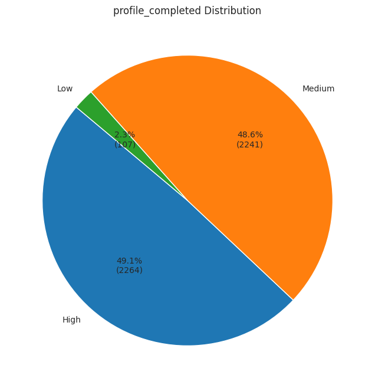

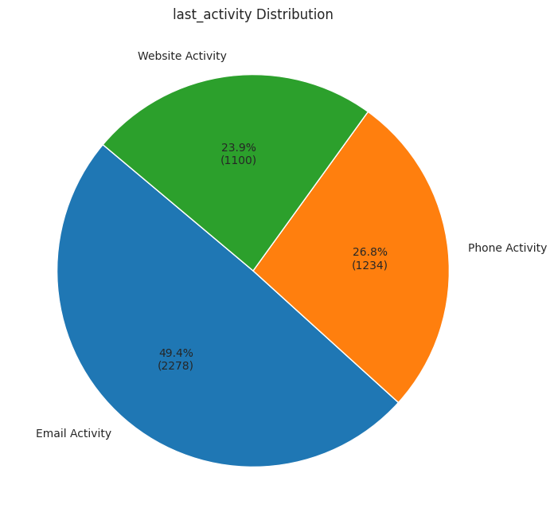

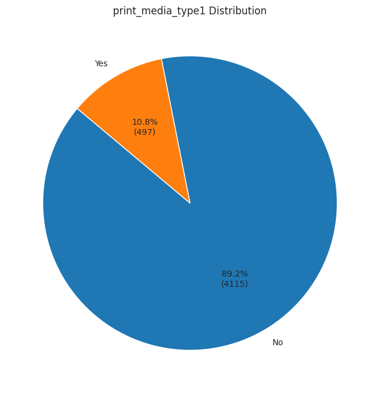

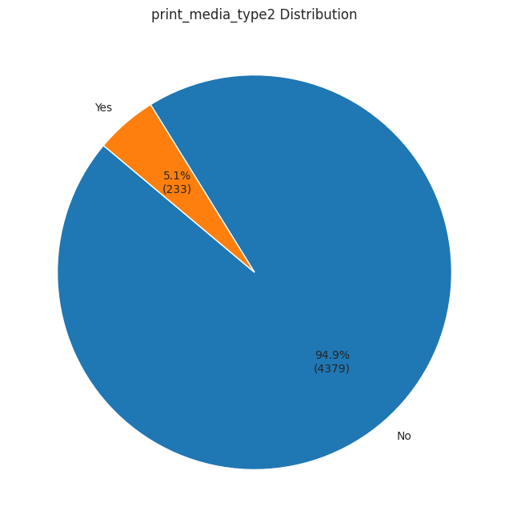

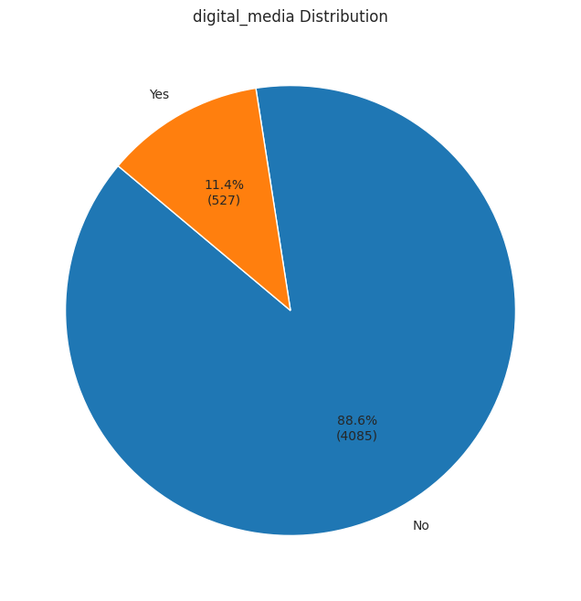

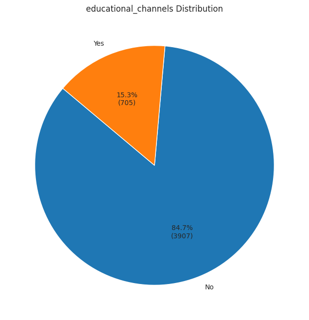

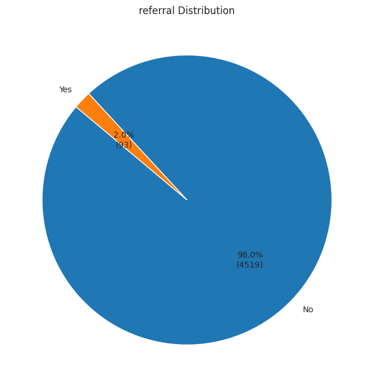

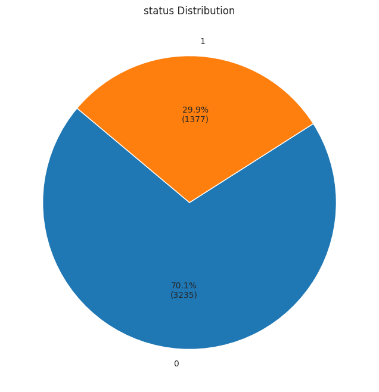

```python
def plot_categorical_distribution(data, column_name):
    # Calculate counts and percentages
    counts = data[column_name].value_counts()
    total = counts.sum()
    percentages = 100 * counts / total

    # Function for formatting autopct
    def autopct_format():
        def my_format(pct):
            total_count = int(round(pct*total/100.0))
            return '{:.1f}%\n({:d})'.format(pct, total_count)
        return my_format  # Return the function itself

    # Plot
    plt.figure(figsize=(8, 8))
    plt.pie(counts, labels=counts.index, autopct=autopct_format(), startangle=140)
    plt.title(f'{column_name} Distribution')
    plt.show()

categorical_data = ['current_occupation','first_interaction','profile_completed','last_activity','print_media_type1', 'print_media_type2','digital_media','educational_channels',
           'referral','status']
for i in categorical_data:
  plot_categorical_distribution(data,i)
```

**Our analysis reveals that the column for current occupation categorizes leads into three distinct groups: 56.7% are Professionals, 31.2% are Unemployed, and 12% are Students.**

**In terms of initial contact, 55.1% of leads were acquired through the website, while the remaining 44.9% came through mobile platforms.**

**Looking at profile completion levels, 49.1% of leads have high profile completion, closely followed by 48.6% with medium, and a small 2.3% with low completion rates.**

**For last activity, email interactions lead with 49.4%, phone interactions are next at 26.8%, and website interactions account for 23.9%.**

**Only 2% of leads discovered ExtraaLearn through references.**

**Combining these insights, we find that 44.4% of leads were generated from those five channels, though it's important to note that some leads were exposed to advertisements across multiple platforms.**

### Multi variable analysis

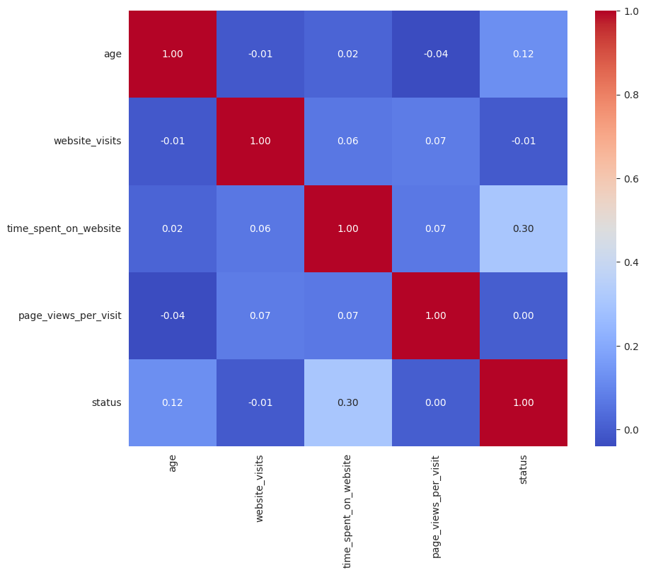

```python
correlation_matrix = data.corr(numeric_only=True)

# Plotting heatmap of the correlation matrix
plt.figure(figsize=(10, 8))
sns.heatmap(correlation_matrix, annot=True, fmt=".2f", cmap='coolwarm', cbar=True)
plt.show()
```

The data reveals that the correlation between status and time spent on the website is positively marked at 0.30, suggesting that as time on the website increases, so does the likelihood of a particular status outcome. This insight is particularly valuable for our model aiming to predict status.

Age also shows a positive correlation with status, albeit a more modest one at 0.12, indicating a slight relationship between the two variables.

Conversely, there appears to be no correlation between status and both website visits and page views per visit, with correlation coefficients of -0.01 and 0.00, respectively, suggesting these factors do not significantly impact status.

Additionally, there are no noteworthy correlations between other variables, indicating a lack of significant relationships outside those mentioned.

#### Answering the suggested questions

1. Leads will have different expectations from the outcome of the course and the current occupation may play a key role in getting them to participate in the program. Find out how current occupation affects lead status.

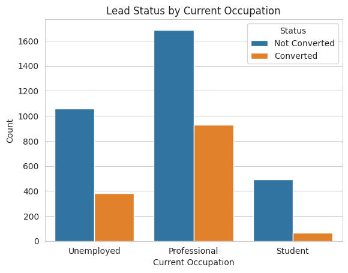

```python
# Bar Plot, leadstatus vs current occupation
sns.countplot(x='current_occupation', hue='status', data=data)
plt.title('Lead Status by Current Occupation')
plt.xlabel('Current Occupation')
plt.ylabel('Count')
plt.legend(title='Status', loc='upper right', labels=['Not Converted', 'Converted'])
plt.show()
```

```python
# Cross-Tabulation
cross_tab = pd.crosstab(data['current_occupation'], data['status'])

# Chi-Square Test
chi2, p, dof, expected = chi2_contingency(cross_tab)

print(cross_tab)
print(f"Chi-Square Statistic: {chi2}, p-value: {p}")
```

```
status                 0    1
current_occupation
Professional        1687  929
Student              490   65
Unemployed          1058  383
Chi-Square Statistic: 134.59904099211036, p-value: 5.918199675434894e-30
```

Based on the results, there is a statistically significant association between a customer's current occupation and their purchasing status for a course. This means that the occupation of a customer is likely to affect their decision to enroll

1. The company's first impression on the customer must have an impact. Do the first channels of interaction have an impact on the lead status?

```python
# Step 1: Cross-tabulation
cross_tab = pd.crosstab(data['first_interaction'], data['status'])

# Step 2: Chi-Square Test
chi2_stat, p_val, dof, expected = chi2_contingency(cross_tab)
print(cross_tab)
# Step 3: Interpret Results
print(f"Chi-Square Statistic: {chi2_stat}")
print(f"p-value: {p_val}")
```

```
status                0     1
first_interaction
Mobile App         1852   218
Website            1383  1159
Chi-Square Statistic: 668.0813826411269
p-value: 2.611251831709229e-147
```

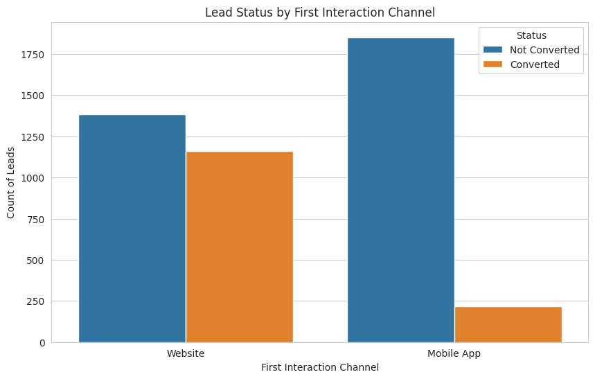

```python
# Setting the aesthetic style of the plots
sns.set_style("whitegrid")

# Plotting
plt.figure(figsize=(10, 6))
sns.countplot(x='first_interaction', hue='status', data=data)
plt.title('Lead Status by First Interaction Channel')
plt.xlabel('First Interaction Channel')
plt.ylabel('Count of Leads')
plt.legend(title='Status', loc='upper right', labels=['Not Converted', 'Converted'])
plt.show()
```

**Individuals who first interact with the mobile app are less likely to convert, whereas those who initially engage with the website have an equal likelihood of conversion.**

1. The company uses multiple modes to interact with prospects. Which way of interaction works best?

```python
activity_conversion_rates = data.groupby('last_activity')['status'].mean().reset_index()
activity_conversion_rates.columns = ['Last Activity', 'Conversion Rate']
activity_conversion_rates_sorted = activity_conversion_rates.sort_values(by='Conversion Rate', ascending=False)
print(activity_conversion_rates_sorted)
```

```
      Last Activity  Conversion Rate
2  Website Activity         0.384545
0    Email Activity         0.303336
1    Phone Activity         0.213128
```

**Website Activity has the best conversion rate**

1. The company gets leads from various channels such as print media, digital media, referrals, etc. Which of these channels have the highest lead conversion rate?

```python
media_columns = ['print_media_type1', 'print_media_type2', 'digital_media', 'educational_channels', 'referral']
conversion_rates = {}

for column in media_columns:
    # Calculate the conversion rate for each media type
    conversion_rate = data[data[column] == 'Yes']['status'].mean()
    conversion_rates[column] = conversion_rate

# Display conversion rates for each media type
conversion_rates_df = pd.DataFrame(list(conversion_rates.items()), columns=['Media Type', 'Conversion Rate'])
conversion_rates_df_sorted = conversion_rates_df.sort_values(by='Conversion Rate', ascending=False)

print(conversion_rates_df_sorted)
```

```
             Media Type  Conversion Rate
4              referral         0.677419
1     print_media_type2         0.321888
0     print_media_type1         0.319920
2         digital_media         0.318786
3  educational_channels         0.279433
```

**Referrals stand out as the most effective means for conversion, while the conversion rates for other types of media are relatively similar to each other.**

1. People browsing the website or mobile application are generally required to create a profile by sharing their personal data before they can access additional information.Does having more details about a prospect increase the chances of conversion?

```python
profile_conversion_rates = data.groupby('profile_completed')['status'].mean().sort_values(ascending=False).reset_index()
print(profile_conversion_rates)
```

```
  profile_completed    status
0              High  0.417845
1            Medium  0.188755
2               Low  0.074766
```

**The data shows that people who fully complete their profiles are most likely to sign up, with a 41.78% sign-up rate. Those with partially completed profiles sign up less often, at 18.88%, and those with barely completed profiles have the lowest sign-up rate of 7.48%. This suggests that encouraging users to complete their profiles could lead to more sign-ups.**

## Data Preprocessing

```python
# lets make a copy in case we need the orignal data
df = data.copy()
# independedient variables
X = df.drop(['status', 'ID'], axis=1)
# depedent variable
Y = df['status']
categorical_data = [
    'current_occupation',
    'first_interaction',
    'profile_completed',
    'print_media_type1',
   'print_media_type2',
    'last_activity',
    'digital_media',
    'educational_channels',
    'referral'
    ]
# ENCODING CATEGORICAL DATA
X = pd.get_dummies(X, columns=categorical_data, drop_first=True)



X.head()
```

|  | age | website_visits | time_spent_on_website | page_views_per_visit | current_occupation_Student | current_occupation_Unemployed | first_interaction_Website | profile_completed_Low | profile_completed_Medium | print_media_type1_Yes | print_media_type2_Yes | last_activity_Phone Activity | last_activity_Website Activity | digital_media_Yes | educational_channels_Yes | referral_Yes |
| --- | --- | --- | --- | --- | --- | --- | --- | --- | --- | --- | --- | --- | --- | --- | --- | --- |
| 0 | 57 | 7 | 1639 | 1.861 | 0 | 1 | 1 | 0 | 0 | 1 | 0 | 0 | 1 | 1 | 0 | 0 |
| 1 | 56 | 2 | 83 | 0.320 | 0 | 0 | 0 | 0 | 1 | 0 | 0 | 0 | 1 | 0 | 1 | 0 |
| 2 | 52 | 3 | 330 | 0.074 | 0 | 0 | 1 | 0 | 1 | 0 | 0 | 0 | 1 | 1 | 0 | 0 |
| 3 | 53 | 4 | 464 | 2.057 | 0 | 1 | 1 | 0 | 0 | 0 | 0 | 0 | 1 | 0 | 0 | 0 |
| 4 | 23 | 4 | 600 | 16.914 | 1 | 0 | 1 | 0 | 0 | 0 | 0 | 0 | 0 | 0 | 0 | 0 |

```python
# Splitting the data in 70:30 ratio for train to test data
X_train, X_test, y_train, y_test = train_test_split(
    X, Y, test_size=0.30, random_state=1
)
```

```python
# Preview the first few rows of the training features
print("X_train preview:")
X_train.head()
```

```
X_train preview:
```

|  | age | website_visits | time_spent_on_website | page_views_per_visit | current_occupation_Student | current_occupation_Unemployed | first_interaction_Website | profile_completed_Low | profile_completed_Medium | print_media_type1_Yes | print_media_type2_Yes | last_activity_Phone Activity | last_activity_Website Activity | digital_media_Yes | educational_channels_Yes | referral_Yes |
| --- | --- | --- | --- | --- | --- | --- | --- | --- | --- | --- | --- | --- | --- | --- | --- | --- |
| 2462 | 57 | 2 | 26 | 0.109 | 0 | 1 | 0 | 0 | 0 | 0 | 0 | 0 | 0 | 0 | 0 | 0 |
| 1621 | 57 | 7 | 385 | 8.201 | 0 | 0 | 1 | 0 | 1 | 0 | 0 | 1 | 0 | 1 | 1 | 0 |
| 197 | 32 | 9 | 2001 | 2.178 | 0 | 1 | 1 | 0 | 1 | 0 | 0 | 0 | 0 | 0 | 0 | 0 |
| 2181 | 34 | 3 | 318 | 3.926 | 0 | 0 | 0 | 0 | 1 | 1 | 0 | 0 | 0 | 0 | 0 | 0 |
| 2867 | 37 | 4 | 211 | 2.010 | 0 | 1 | 0 | 1 | 0 | 1 | 0 | 0 | 0 | 0 | 0 | 0 |

```python
# Preview the first few rows of the training labels
print("\ny_train preview:")
y_train.head()
```

```
y_train preview:
```

```
2462    0
1621    0
197     0
2181    0
2867    0
Name: status, dtype: int64
```

```python
# Preview the first few rows of the test features
print("\nX_test preview:")
X_test.head()
```

```
X_test preview:
```

|  | age | website_visits | time_spent_on_website | page_views_per_visit | current_occupation_Student | current_occupation_Unemployed | first_interaction_Website | profile_completed_Low | profile_completed_Medium | print_media_type1_Yes | print_media_type2_Yes | last_activity_Phone Activity | last_activity_Website Activity | digital_media_Yes | educational_channels_Yes | referral_Yes |
| --- | --- | --- | --- | --- | --- | --- | --- | --- | --- | --- | --- | --- | --- | --- | --- | --- |
| 3823 | 18 | 5 | 202 | 2.194 | 1 | 0 | 0 | 0 | 1 | 0 | 0 | 0 | 1 | 0 | 0 | 0 |
| 190 | 19 | 3 | 288 | 3.586 | 1 | 0 | 0 | 0 | 0 | 0 | 0 | 1 | 0 | 1 | 0 | 0 |
| 2611 | 54 | 5 | 1902 | 3.744 | 0 | 1 | 1 | 0 | 1 | 0 | 0 | 0 | 1 | 0 | 0 | 0 |
| 2404 | 63 | 2 | 85 | 8.597 | 0 | 1 | 0 | 0 | 1 | 0 | 0 | 0 | 0 | 0 | 1 | 0 |
| 4269 | 19 | 3 | 81 | 2.124 | 1 | 0 | 0 | 0 | 0 | 0 | 0 | 0 | 0 | 0 | 1 | 0 |

```python
# Preview the first few rows of the test labels
print("\ny_test preview:")
y_test.head()
```

```
y_test preview:
```

```
3823    0
190     0
2611    1
2404    0
4269    0
Name: status, dtype: int64
```

## Building a Decision Tree model

```python
clf = DecisionTreeClassifier(random_state=42)
clf.fit(X_train, y_train)
```

```
DecisionTreeClassifier(random_state=42)
```

## Model Performance evaluation and improvement

```python
def evaluate_model(y_true, y_pred):
    """
    Evaluates the performance of a model on test data.

    Args:
    - y_true: Actual target values.
    - y_pred: Predicted target values by the model.
    """
    # Calculate and print the F1 score
    print(f'F1 score for test set: {f1_score(y_true, y_pred):.4f}')
    print('-' * 60)  # Printing a separator line for clarity

    # Print classification report
    print('Classification Report:\n', classification_report(y_true, y_pred))

    # Calculate the confusion matrix
    cm = confusion_matrix(y_true, y_pred)

    # Create a figure for the heatmap
    plt.figure(figsize=(8, 6))

    # Create a heatmap
    sns.heatmap(cm, annot=True, fmt='d', cmap='Blues',
                xticklabels=['Not Converted', 'Converted'],
                yticklabels=['Not Converted', 'Converted'],
                cbar=False)

    plt.ylabel('Actual')
    plt.xlabel('Predicted')
    plt.title('Confusion Matrix')
    plt.show()
```

```
F1 score for test set: 1.0000
------------------------------------------------------------
Classification Report:
               precision    recall  f1-score   support

           0       1.00      1.00      1.00      2273
           1       1.00      1.00      1.00       955

    accuracy                           1.00      3228
   macro avg       1.00      1.00      1.00      3228
weighted avg       1.00      1.00      1.00      3228
```

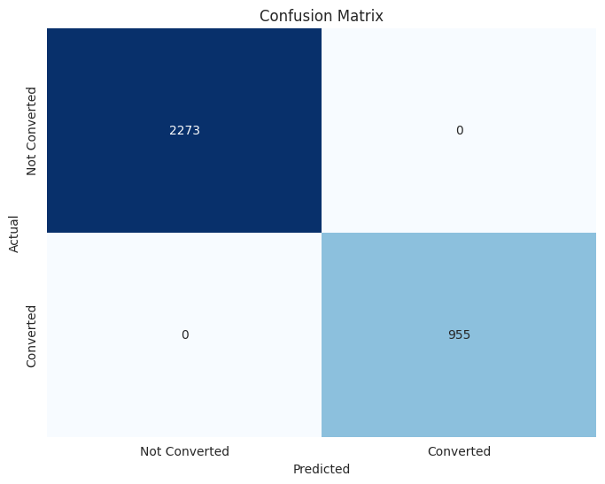

```python
y_pred_train1 = clf.predict(X_train)  # Storing model predictions for the training data
evaluate_model(y_train, y_pred_train1)
```

However, such perfect results are rare in real-world scenarios and might indicate issues like overfitting (the model is too closely fitted to the training data and may not perform well on new data), a non-representative test set, or possible data leakage (the model had access to information it should not have). To ensure the model is truly effective, further checks and validations are recommended.

```
F1 score for test set: 0.6887
------------------------------------------------------------
Classification Report:
               precision    recall  f1-score   support

           0       0.86      0.86      0.86       962
           1       0.69      0.69      0.69       422

    accuracy                           0.81      1384
   macro avg       0.77      0.78      0.78      1384
weighted avg       0.81      0.81      0.81      1384
```

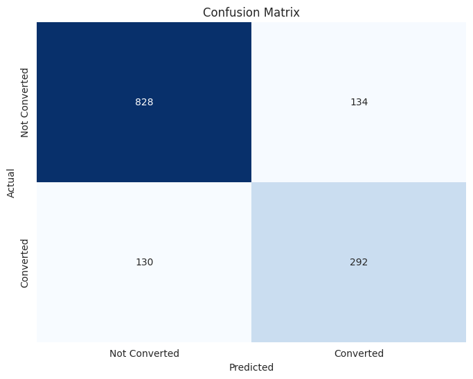

```python
# Assuming clf is your trained classifier and X_test, y_test are your test dataset
y_pred_test1 = clf.predict(X_test)  # Storing model predictions for the test data

# Evaluate the model
evaluate_model(y_test, y_pred_test1)
```

The updated test results show that the model does well but isn't perfect:

- The F1 score is 0.69, showing a good balance in the model's accuracy for both predicting and missing cases.
- It predicts correctly 86% of the time for one class and 69% for the other, with an overall accuracy of 81%.
- This means it's right 81% of the time across all predictions.

These results are more realistic and show the model is effective but could still be improved, especially for the class with lower scores.

```python
# Function to compute adjusted R-squared
def adj_r2_score(predictors, targets, predictions):
    r2 = r2_score(targets, predictions)
    n = predictors.shape[0]
    k = predictors.shape[1]
    return 1 - ((1 - r2) * (n - 1) / (n - k - 1))


# Function to compute MAPE
def mape_score(targets, predictions):
    return np.mean(np.abs(targets - predictions) / targets) * 100


# Function to compute different metrics to check performance of a regression model
def model_performance_regression(model, predictors, target):
    """
    Function to compute different metrics to check regression model performance

    model: regressor
    predictors: independent variables
    target: dependent variable
    """

    pred = model.predict(predictors)                  # Predict using the independent variables
    r2 = r2_score(target, pred)                       # To compute R-squared
    adjr2 = adj_r2_score(predictors, target, pred)    # To compute adjusted R-squared
    rmse = np.sqrt(mean_squared_error(target, pred))  # To compute RMSE
    mae = mean_absolute_error(target, pred)           # To compute MAE

    # Creating a dataframe of metrics
    df_perf = pd.DataFrame(
        {
            "RMSE": rmse,
            "MAE": mae,
            "R-squared": r2,
            "Adj. R-squared": adjr2,
        },
        index=[0],
    )

    return df_perf
```

```python
dt_regressor_perf_test = model_performance_regression(clf, X_test, y_test)
dt_regressor_perf_test
```

|  | RMSE | MAE | R-squared | Adj. R-squared |
| --- | --- | --- | --- | --- |
| 0 | 0.435923 | 0.190029 | 0.103388 | 0.092894 |

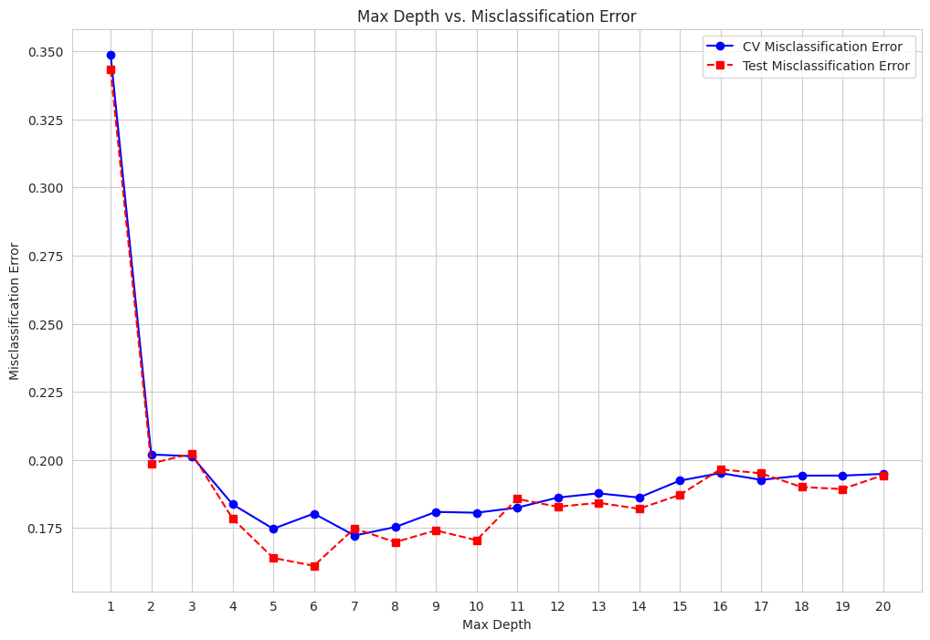

```python
def evaluate_model_depth_with_test(X_train, y_train, X_test, y_test, depth_range, cv_folds=5):
    """Evaluates Decision Tree model over a range of depths using both cross-validation on the training set
    and evaluation on the test set.

    Args:
        X_train (DataFrame): Training features.
        y_train (Series): Training target variable.
        X_test (DataFrame): Test features.
        y_test (Series): Test target variable.
        depth_range (range): Range of depths to evaluate.
        cv_folds (int): Number of folds for cross-validation.

    Returns:
        DataFrame: Contains average cross-validated scores for each depth and test set scores.
    """
    cv_scores = []
    test_errors = []

    for depth in depth_range:
        # class 1 has more importance
        clf = DecisionTreeClassifier(max_depth=depth, random_state=42, class_weight = {0: 0.3, 1: 0.7})

        # Cross-validation on training data
        scores = cross_val_score(clf, X_train, y_train, cv=cv_folds, scoring='neg_mean_squared_error')
        cv_scores.append(np.mean(scores))

        # Training and evaluating on test data
        clf.fit(X_train, y_train)
        y_test_pred = clf.predict(X_test)
        test_error = mean_squared_error(y_test, y_test_pred)
        test_errors.append(test_error)

    return pd.DataFrame({
        'Max Depth': depth_range,
        'CV Score': cv_scores,
        'Test Error': test_errors
    })

# Assuming depth_range is defined as before
depth_range = range(1, 21)

# Evaluate the model across the defined range of depths, including test data
results = evaluate_model_depth_with_test(X_train, y_train, X_test, y_test, depth_range)

# Convert the scores to positive; higher is better for CV Score, lower is better for Test Error
results['CV Misclassification Error'] = -results['CV Score']
results['Test Misclassification Error'] = results['Test Error']

# Plotting
plt.figure(figsize=(12, 8))
plt.plot(results['Max Depth'], results['CV Misclassification Error'], marker='o', linestyle='-', color='b', label='CV Misclassification Error')
plt.plot(results['Max Depth'], results['Test Misclassification Error'], marker='s', linestyle='--', color='r', label='Test Misclassification Error')
plt.title('Max Depth vs. Misclassification Error')
plt.xlabel('Max Depth')
plt.ylabel('Misclassification Error')
plt.grid(True)
plt.xticks(depth_range)
plt.legend()
plt.show()
```

```python
# find the best possible tree from tunning hyperparameters

# Define the model
# pay more attention to class 1, (CHECK EDA for status)
dt_tuned = DecisionTreeClassifier(random_state=42,class_weight = {0: 0.3, 1: 0.7})

# Define the parameter grid
param_grid = {
  'max_depth': np.arange(2, 11),
  'criterion': ['gini', 'entropy'],
  'min_samples_leaf': [5, 10, 15, 20, 25],
}

# Instantiate the GridSearchCV object
grid_search = GridSearchCV(estimator=dt_tuned, param_grid=param_grid, scoring='accuracy', cv=5)

# Fit to the data
grid_search.fit(X_train, y_train)

# Best parameters and best score
print("Best parameters:", grid_search.best_params_)
print("Best score:", grid_search.best_score_)
```

```
Best parameters: {'criterion': 'entropy', 'max_depth': 5, 'min_samples_leaf': 20}
Best score: 0.832407900736794
```

```
F1 score for test set: 0.7623
------------------------------------------------------------
Classification Report:
               precision    recall  f1-score   support

           0       0.92      0.84      0.88       962
           1       0.70      0.84      0.76       422

    accuracy                           0.84      1384
   macro avg       0.81      0.84      0.82      1384
weighted avg       0.85      0.84      0.84      1384
```

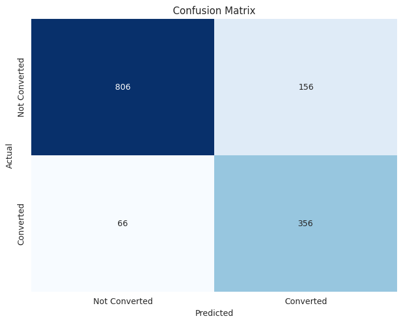

```python
dt_tuned = grid_search.best_estimator_
y_pred_test2 = dt_tuned.predict(X_test)

# Evaluate the model
evaluate_model(y_test, y_pred_test2)
```

After performing a GridSearch to optimize the decision tree, the evaluation metrics improved:

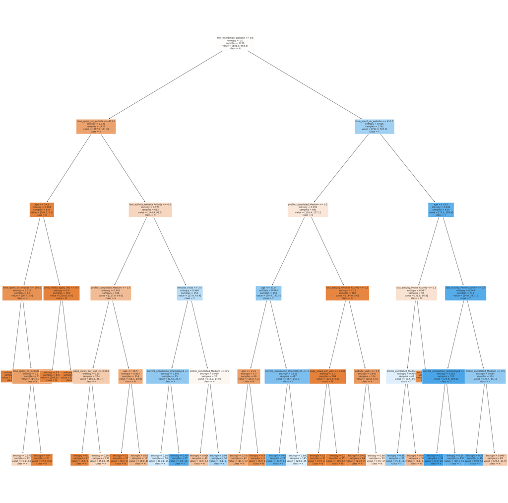

```python
plt.figure(figsize=(40, 40))
plot_tree(dt_tuned, filled=True, feature_names=X_train.columns, class_names=['N', 'Y'], # limits the width of the pure nodes
          fontsize=10, max_depth=5)
plt.show()
```

The decision tree reveals several key observations about factors influencing conversion:

**Time Spent on Website**: Higher time spent on the website generally leads to more nuanced pathways for conversion. For users who spend more than 419.5 units of time on the website, their activities, such as website activity and profile completion level, start to play a significant role in their likelihood of conversion.

**Print Media and Website Activity**: Interestingly, print media interaction (type 1) and specific last activities (like website activity) influence conversion paths. Individuals engaged in website activities after spending considerable time on the website, and those with no print media interaction (type 1), are more likely to be in the non-conversion group unless other factors like website visits and current occupation come into play favorably.

**Occupation and Conversion**: The current occupation, particularly unemployment status, significantly affects conversion chances. Unemployed individuals show varying conversion rates based on their engagement level, profile completion, and last activity type, highlighting the importance of employment status in the conversion process.

**Digital Engagement**: Detailed engagement metrics like page views per visit and last activity type (phone activity, website activity) alongside demographic factors (age) and time spent on the website present a complex interaction of variables influencing the likelihood of conversion.

These observations underscore the complexity of the conversion process, highlighting the need to consider a multifaceted approach that includes demographic factors, engagement metrics, and interaction types when aiming to increase conversion rates.

```
                           Feature    Importance
2            time_spent_on_website  2.900961e-01
6        first_interaction_Website  2.632972e-01
8         profile_completed_Medium  2.255889e-01
0                              age  8.418070e-02
5    current_occupation_Unemployed  4.971700e-02
11    last_activity_Phone Activity  3.838281e-02
12  last_activity_Website Activity  3.433807e-02
1                   website_visits  8.098426e-03
3             page_views_per_visit  6.300794e-03
9            print_media_type1_Yes  1.897383e-16
4       current_occupation_Student  0.000000e+00
7            profile_completed_Low  0.000000e+00
10           print_media_type2_Yes  0.000000e+00
13               digital_media_Yes  0.000000e+00
14        educational_channels_Yes  0.000000e+00
15                    referral_Yes  0.000000e+00
```

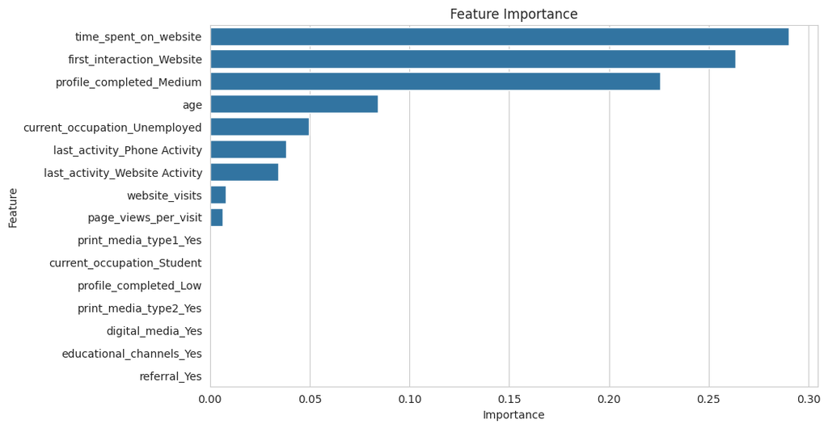

```python
importances = dt_tuned.feature_importances_

# Get the feature names
feature_names = X_train.columns

# Create a DataFrame for easier visualization
feature_importances = pd.DataFrame({'Feature': feature_names, 'Importance': importances})

# Sort the DataFrame to display the most important features at the top
feature_importances = feature_importances.sort_values(by='Importance', ascending=False)

# Display the feature importances
print(feature_importances)

plt.figure(figsize=(10, 6))
sns.barplot(x='Importance', y='Feature', data=feature_importances)
plt.title('Feature Importance')
plt.xlabel('Importance')
plt.ylabel('Feature')
plt.show()
```

The feature importance analysis provides insightful conclusions regarding the factors that most significantly impact conversion rates:

Overall, these conclusions highlight the paramount importance of engaging users on the website, both initially and over time, and ensuring they achieve a medium level of profile completion. Age and employment status are also relevant but to a lesser degree. Marketing strategies and platform improvements should prioritize enhancing user engagement and simplifying the profile completion process to boost conversion rates.

## Building a Random Forest model

```
F1 score for test set: 0.7471
------------------------------------------------------------
Classification Report:
               precision    recall  f1-score   support

           0       0.87      0.93      0.90       962
           1       0.81      0.70      0.75       422

    accuracy                           0.86      1384
   macro avg       0.84      0.81      0.82      1384
weighted avg       0.85      0.86      0.85      1384
```

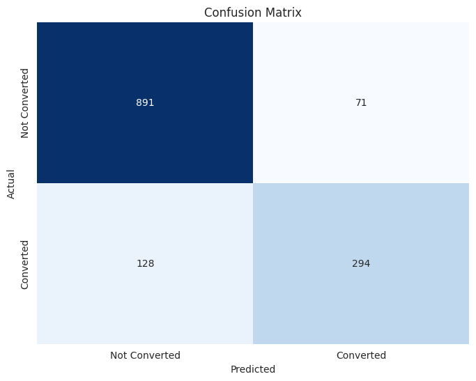

```python
rf = RandomForestClassifier(n_estimators=100, random_state=42)

# Train the model on the training data
rf.fit(X_train, y_train)

# Predictions on the training set
y_pred_train = rf.predict(X_train)

# Predictions on the test set
y_pred_test_ran = rf.predict(X_test)

# Evaluate the model
evaluate_model(y_test, y_pred_test_ran)
```

The evaluation of the random forest model without tuning presents the following performance metrics:

- The F1 score for the test set stands at 0.7471, reflecting a strong balance between precision and recall, particularly for a model that hasn't been fine-tuned.
- Precision rates are high, with 0.87 for class 0 and 0.81 for class 1, indicating the model's accuracy in predicting true positives across both classes.
- Recall rates show the model's strength in identifying class 0 at 0.93 and a slightly lower capability for class 1 at 0.70, suggesting it's better at correctly identifying true positives for class 0.
- The overall accuracy of the model is 86%, demonstrating its ability to correctly classify the majority of cases in the test set.

These results highlight the random forest model's effectiveness in classifying the given dataset, with strong performance across precision, recall, and accuracy. Despite not being tuned, the model shows promise, particularly in its ability to predict class 0 with high precision and recall. Further tuning could potentially enhance its performance, especially in improving recall for class 1.

## Model Performance evaluation and improvement

```python
param_grid = {
    'n_estimators': [100, 200, 300],
    'max_depth': [10, 20, 30],
    'min_samples_split': [2, 5, 10],
    'min_samples_leaf': [2, 10, 20],
    'max_features': ['sqrt']
}
rf = RandomForestClassifier(random_state=42)
scorer = metrics.make_scorer(recall_score, pos_label = 1)
# Instantiate the grid search model
grid_search = GridSearchCV(estimator=rf, param_grid=param_grid,
                           scoring=scorer, cv=3, n_jobs=-1, verbose=2)

grid_search.fit(X_train, y_train)

print("Best parameters:", grid_search.best_params_)

# Best score
print("Best score:", grid_search.best_score_)

# Get the best estimator directly
best_rf = grid_search.best_estimator_
best_rf.fit(X_train, y_train)
```

```
Fitting 3 folds for each of 81 candidates, totalling 243 fits
Best parameters: {'max_depth': 10, 'max_features': 'sqrt', 'min_samples_leaf': 2, 'min_samples_split': 2, 'n_estimators': 100}
Best score: 0.7204346654574371
```

```
RandomForestClassifier(max_depth=10, min_samples_leaf=2, random_state=42)
```

```
Test Accuracy:  0.8554913294797688
F1 score for test set: 0.7481
------------------------------------------------------------
Classification Report:
               precision    recall  f1-score   support

           0       0.88      0.92      0.90       962
           1       0.80      0.70      0.75       422

    accuracy                           0.86      1384
   macro avg       0.84      0.81      0.82      1384
weighted avg       0.85      0.86      0.85      1384
```

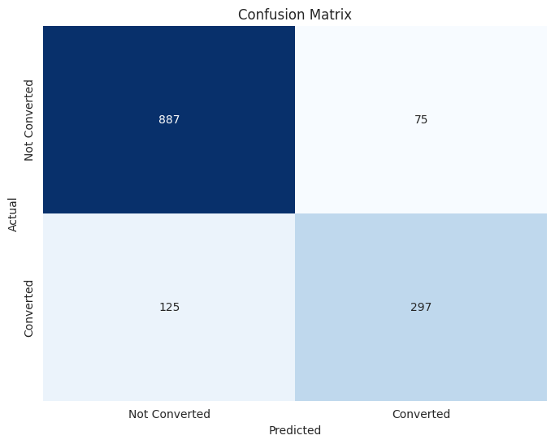

```python
y_pred_test_ran_t = best_rf.predict(X_test)

# Evaluate the model
print("Test Accuracy: ", accuracy_score(y_test, y_pred_test_ran_t))

evaluate_model(y_test, y_pred_test_ran_t)
```

After fine-tuning the random forest model with GridSearch, the performance metrics are as follows:

The GridSearch optimization of the random forest model resulted in a refined performance, maintaining its strong predictive accuracy while slightly improving the balance between precision and recall. This demonstrates the effectiveness of model tuning in enhancing the overall predictive quality, especially in maintaining high performance in precision and recall across both classes.

```
                           Feature  Importance
2            time_spent_on_website    0.280588
6        first_interaction_Website    0.250990
8         profile_completed_Medium    0.135014
0                              age    0.070407
3             page_views_per_visit    0.064339
11    last_activity_Phone Activity    0.037163
1                   website_visits    0.034520
5    current_occupation_Unemployed    0.031928
4       current_occupation_Student    0.027374
12  last_activity_Website Activity    0.021606
7            profile_completed_Low    0.017104
15                    referral_Yes    0.009184
9            print_media_type1_Yes    0.006014
14        educational_channels_Yes    0.005775
13               digital_media_Yes    0.005245
10           print_media_type2_Yes    0.002750
```

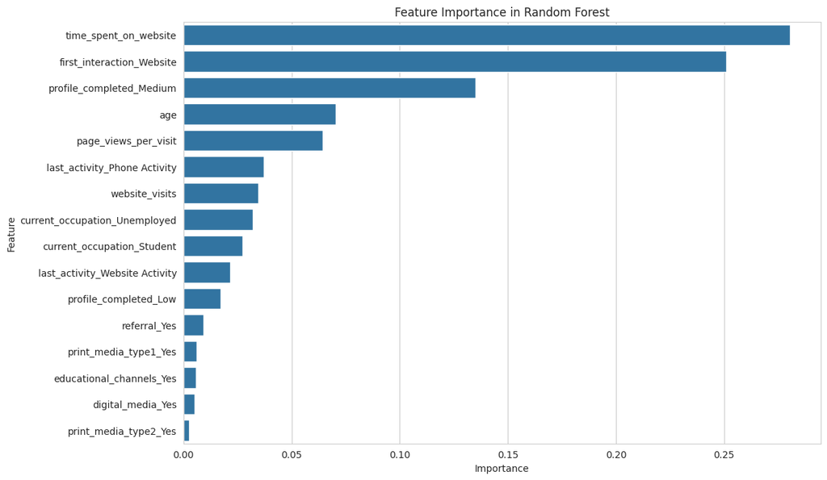

```python
# Get feature importances
importances = best_rf.feature_importances_

# Get the feature names
feature_names = X_train.columns

# Create a DataFrame for easier visualization
feature_importances_df = pd.DataFrame({'Feature': feature_names, 'Importance': importances})

# Sort the DataFrame to display the most important features at the top
feature_importances_df = feature_importances_df.sort_values(by='Importance', ascending=False)

# Display the feature importances
print(feature_importances_df)

# Optional: For a visual representation, plot the feature importances
plt.figure(figsize=(12, 8))
sns.barplot(x='Importance', y='Feature', data=feature_importances_df)
plt.title('Feature Importance in Random Forest')
plt.xlabel('Importance')
plt.ylabel('Feature')
plt.show()
```

Analyzing the Random Forest model's feature importance provides several key insights into factors that significantly influence conversion rates:

Time Spent on the Website: This remains the most critical factor, underscoring the importance of engaging content and user experience to keep visitors on the site longer.

Overall, the Random Forest analysis emphasizes the importance of a website's initial and ongoing engagement, the balancing act in profile completion, and the value of understanding user demographics and behaviors. Tailoring marketing strategies to enhance these areas can lead to higher conversion rates, with a focus on creating a positive and engaging online environment from the first interaction.

## Actionable Insights and Recommendations

Drawing from the classification model's feature importance and exploratory data analysis (EDA), we've identified key drivers of conversion, notably:

- Significant time spent on the website.
- Initial interaction via the website.
- Profiles completed to a medium level or higher.

Additional influences include:

- Engagement in professional activities, especially among non-students and individuals in later career stages.
- Engagement patterns, such as the last activity being through the website, hint at higher conversion likelihood.
- The potential impact of referrals on the decision to convert, indicating that targeted leads, particularly late-career professionals who are either working or unemployed and who engage deeply with the website, show a higher propensity to convert.

However, the EDA highlighted some challenges:

- The model's current inability to fully grasp the impact of various advertising channels on conversion rates.
- A lack of insight into the synergistic effects of multiple advertising mediums.
- Lower conversion rates for leads who engage first through the mobile app compared to those whose initial interaction is via the website.
- An absence of detailed data on how leads interact with the website content.

To address these findings, we propose the following strategic recommendations:

**Understanding Lead Behavior:** Invest in analytics to gain deeper insights into lead activities on the website. Understanding the specifics of user engagement can inform more targeted conversion strategies.

**Enhance Website Engagement:** Focus on enriching the website's user experience and design. Investments in improving both the front-end aesthetics and back-end functionality could make the website more engaging and compelling for visitors.

**Refine Advertising Strategy:** Given the unclear impact of advertising channels, a deeper analysis is warranted. Emphasizing referral programs or exploring new advertising strategies based on detailed channel performance could improve overall conversion effectiveness.

**App Development Insights:** Reevaluate the mobile app's user experience. Consider conducting user research to identify potential shortcomings or areas for enhancement to increase app engagement and conversion rates.

**Tailored Promotional Offers:** Implement targeted offers for segments with lower conversion rates, such as students. Customized promotions or discounts could incentivize conversions among these groups.

**Incentivize Profile Completion:** Encourage users to complete their profiles by streamlining the process or offering incentives for completion. A more engaging onboarding experience could significantly enhance profile completion rates.

Implementing these recommendations could lead to more effective conversion strategies, optimized resource allocation, and ultimately, a higher return on investment in marketing and development efforts.